# Individual differences

In **Pilot 1**, there are 27 subjects who did the curiosity personal trait questionaire. The following analysis will only include these subjects who had personal trait scores.

# 1 Relationship between trait score and slope of curiosity-memory relationship

## 1.1 Outside

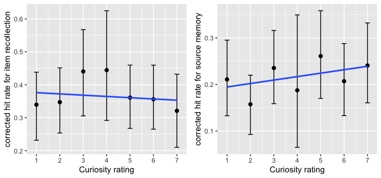

### 1.1.1 Item recollection

#### 1.1.1.1 Correlation with the average score

|  | Model | df | AIC | BIC | logLik | Test | L.Ratio | p-value |
| --- | --- | --- | --- | --- | --- | --- | --- | --- |
| baseline.rating | 1 | 3 | -1.839940 | 6.472113 | 3.919970 |  |  |  |
| rating.intercept | 2 | 4 | 0.159780 | 11.242518 | 3.920110 | 1 vs 2 | 0.0002801 | 0.9866 |
| rating.slope | 3 | 6 | 4.159910 | 20.784018 | 3.920045 | 2 vs 3 | 0.0001306 | 0.9999 |
| tr.intercept | 4 | 7 | 5.242936 | 24.637728 | 4.378532 | 3 vs 4 | 0.9169741 | 0.3383 |
| tr.slope | 5 | 8 | 7.242924 | 29.408401 | 4.378538 | 4 vs 5 | 0.0000117 | 0.9973 |

#### 1.1.1.2 Correlation with the PC score

|  | Model | df | AIC | BIC | logLik | Test | L.Ratio | p-value |
| --- | --- | --- | --- | --- | --- | --- | --- | --- |
| baseline.rating | 1 | 3 | -1.839940 | 6.472113 | 3.919970 |  |  |  |
| rating.intercept | 2 | 4 | 0.159780 | 11.242518 | 3.920110 | 1 vs 2 | 0.0002801 | 0.9866 |
| rating.slope | 3 | 6 | 4.159910 | 20.784018 | 3.920045 | 2 vs 3 | 0.0001306 | 0.9999 |
| PC.intercept | 4 | 7 | 5.694020 | 25.088812 | 4.152990 | 3 vs 4 | 0.4658903 | 0.4949 |
| PC.slope | 5 | 8 | 7.466475 | 29.631952 | 4.266763 | 4 vs 5 | 0.2275450 | 0.6334 |

#### 1.1.1.3 Correlation with the EC score

|  | Model | df | AIC | BIC | logLik | Test | L.Ratio | p-value |
| --- | --- | --- | --- | --- | --- | --- | --- | --- |
| baseline.rating | 1 | 3 | -1.839940 | 6.472113 | 3.919970 |  |  |  |
| rating.intercept | 2 | 4 | 0.159780 | 11.242518 | 3.920110 | 1 vs 2 | 0.0002801 | 0.9866 |
| rating.slope | 3 | 6 | 4.159910 | 20.784018 | 3.920045 | 2 vs 3 | 0.0001306 | 0.9999 |
| EC.intercept | 4 | 7 | 5.203178 | 24.597970 | 4.398411 | 3 vs 4 | 0.9567321 | 0.3280 |
| EC.slope | 5 | 8 | 7.016034 | 29.181511 | 4.491983 | 4 vs 5 | 0.1871439 | 0.6653 |

### 1.1.2 Source memory

#### 1.1.2.1 Correlation with the average score

|  | Model | df | AIC | BIC | logLik | Test | L.Ratio | p-value |
| --- | --- | --- | --- | --- | --- | --- | --- | --- |
| baseline.rating | 1 | 3 | -60.47996 | -52.16791 | 33.23998 |  |  |  |
| rating.intercept | 2 | 4 | -59.41549 | -48.33276 | 33.70775 | 1 vs 2 | 0.9355309 | 0.3334 |
| rating.slope | 3 | 6 | -55.75264 | -39.12853 | 33.87632 | 2 vs 3 | 0.3371477 | 0.8449 |
| tr.intercept | 4 | 7 | -54.34326 | -34.94847 | 34.17163 | 3 vs 4 | 0.5906202 | 0.4422 |
| tr.slope | 5 | 8 | -52.58250 | -30.41702 | 34.29125 | 4 vs 5 | 0.2392363 | 0.6248 |

#### 1.1.2.2 Correlation with the PC score

|  | Model | df | AIC | BIC | logLik | Test | L.Ratio | p-value |
| --- | --- | --- | --- | --- | --- | --- | --- | --- |
| baseline.rating | 1 | 3 | -60.47996 | -52.16791 | 33.23998 |  |  |  |
| rating.intercept | 2 | 4 | -59.41549 | -48.33276 | 33.70775 | 1 vs 2 | 0.9355309 | 0.3334 |
| rating.slope | 3 | 6 | -55.75264 | -39.12853 | 33.87632 | 2 vs 3 | 0.3371477 | 0.8449 |
| PC.intercept | 4 | 7 | -53.81951 | -34.42471 | 33.90975 | 3 vs 4 | 0.0668641 | 0.7960 |
| PC.slope | 5 | 8 | -51.91058 | -29.74510 | 33.95529 | 4 vs 5 | 0.0910717 | 0.7628 |

#### 1.1.2.3 Correlation with the EC score

|  | Model | df | AIC | BIC | logLik | Test | L.Ratio | p-value |
| --- | --- | --- | --- | --- | --- | --- | --- | --- |
| baseline.rating | 1 | 3 | -60.47996 | -52.16791 | 33.23998 |  |  |  |
| rating.intercept | 2 | 4 | -59.41549 | -48.33276 | 33.70775 | 1 vs 2 | 0.9355309 | 0.3334 |
| rating.slope | 3 | 6 | -55.75264 | -39.12853 | 33.87632 | 2 vs 3 | 0.3371477 | 0.8449 |
| EC.intercept | 4 | 7 | -54.80395 | -35.40916 | 34.40198 | 3 vs 4 | 1.0513085 | 0.3052 |
| EC.slope | 5 | 8 | -53.05716 | -30.89168 | 34.52858 | 4 vs 5 | 0.2532092 | 0.6148 |

## 1.2 Inside

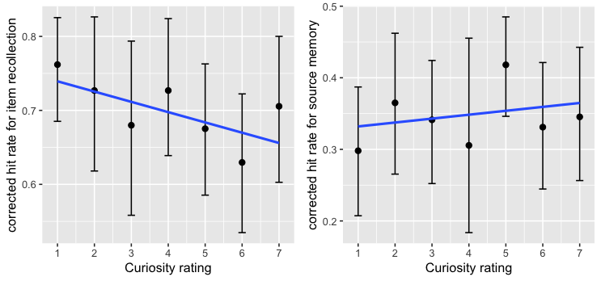

### 1.2.1 Item recollection

#### 1.2.1.1 Correlation with the average score

|  | Model | df | AIC | BIC | logLik | Test | L.Ratio | p-value |
| --- | --- | --- | --- | --- | --- | --- | --- | --- |
| baseline.rating | 1 | 3 | -58.90848 | -49.91684 | 32.45424 |  |  |  |
| rating.intercept | 2 | 4 | -62.91877 | -50.92993 | 35.45939 | 1 vs 2 | 6.010295 | 0.0142 |
| rating.slope | 3 | 6 | -58.92295 | -40.93967 | 35.46147 | 2 vs 3 | 0.004173 | 0.9979 |
| tr.intercept | 4 | 7 | -59.12057 | -38.14009 | 36.56029 | 3 vs 4 | 2.197627 | 0.1382 |
| tr.slope | 5 | 8 | -57.14769 | -33.16999 | 36.57384 | 4 vs 5 | 0.027115 | 0.8692 |

#### 1.2.1.2 Correlation with the PC score

|  | Model | df | AIC | BIC | logLik | Test | L.Ratio | p-value |
| --- | --- | --- | --- | --- | --- | --- | --- | --- |
| baseline.rating | 1 | 3 | -58.90848 | -49.91684 | 32.45424 |  |  |  |
| rating.intercept | 2 | 4 | -62.91877 | -50.92993 | 35.45939 | 1 vs 2 | 6.010295 | 0.0142 |
| rating.slope | 3 | 6 | -58.92295 | -40.93967 | 35.46147 | 2 vs 3 | 0.004173 | 0.9979 |
| PC.intercept | 4 | 7 | -59.91886 | -38.93838 | 36.95943 | 3 vs 4 | 2.995914 | 0.0835 |
| PC.slope | 5 | 8 | -57.99281 | -34.01511 | 36.99641 | 4 vs 5 | 0.073949 | 0.7857 |

```
                  Value   Std.Error  DF   t-value      p-value
(Intercept)  1.13948430 0.223295451 120  5.103034 1.268071e-06
CurRating   -0.01644038 0.006724467 120 -2.444859 1.594364e-02
PC          -0.13756176 0.078320181  25 -1.756402 9.126444e-02
```

#### 1.2.1.3 Correlation with the EC score

|  | Model | df | AIC | BIC | logLik | Test | L.Ratio | p-value |
| --- | --- | --- | --- | --- | --- | --- | --- | --- |
| baseline.rating | 1 | 3 | -58.90848 | -49.91684 | 32.45424 |  |  |  |
| rating.intercept | 2 | 4 | -62.91877 | -50.92993 | 35.45939 | 1 vs 2 | 6.010295 | 0.0142 |
| rating.slope | 3 | 6 | -58.92295 | -40.93967 | 35.46147 | 2 vs 3 | 0.004173 | 0.9979 |
| EC.intercept | 4 | 7 | -57.85638 | -36.87590 | 35.92819 | 3 vs 4 | 0.933436 | 0.3340 |
| EC.slope | 5 | 8 | -55.85793 | -31.88023 | 35.92896 | 4 vs 5 | 0.001542 | 0.9687 |

### 1.2.2 Source memory

#### 1.2.2.1 Correlation with the average score

|  | Model | df | AIC | BIC | logLik | Test | L.Ratio | p-value |
| --- | --- | --- | --- | --- | --- | --- | --- | --- |
| baseline.rating | 1 | 3 | -38.02375 | -29.032110 | 22.01187 |  |  |  |
| rating.intercept | 2 | 4 | -36.17609 | -24.187240 | 22.08805 | 1 vs 2 | 0.1523427 | 0.6963 |
| rating.slope | 3 | 6 | -33.04241 | -15.059134 | 22.52120 | 2 vs 3 | 0.8663187 | 0.6485 |
| tr.intercept | 4 | 7 | -33.32973 | -12.349248 | 23.66487 | 3 vs 4 | 2.2873261 | 0.1304 |
| tr.slope | 5 | 8 | -31.34717 | -7.369469 | 23.67358 | 4 vs 5 | 0.0174335 | 0.8950 |

#### 1.2.2.2 Correlation with the PC score

|  | Model | df | AIC | BIC | logLik | Test | L.Ratio | p-value |
| --- | --- | --- | --- | --- | --- | --- | --- | --- |
| baseline.rating | 1 | 3 | -38.02375 | -29.032110 | 22.01187 |  |  |  |
| rating.intercept | 2 | 4 | -36.17609 | -24.187240 | 22.08805 | 1 vs 2 | 0.152343 | 0.6963 |
| rating.slope | 3 | 6 | -33.04241 | -15.059134 | 22.52120 | 2 vs 3 | 0.866319 | 0.6485 |
| PC.intercept | 4 | 7 | -34.90812 | -13.927632 | 24.45406 | 3 vs 4 | 3.865710 | 0.0493 |
| PC.slope | 5 | 8 | -32.91773 | -8.940035 | 24.45887 | 4 vs 5 | 0.009615 | 0.9219 |

```
                   Value   Std.Error  DF    t-value      p-value
(Intercept)  0.636145502 0.154778090 120  4.1100488 7.268976e-05
CurRating    0.003571481 0.008190062 120  0.4360749 6.635659e-01
PC          -0.109418093 0.054211044  25 -2.0183727 5.440265e-02
```

#### 1.2.2.3 Correlation with the EC score

|  | Model | df | AIC | BIC | logLik | Test | L.Ratio | p-value |
| --- | --- | --- | --- | --- | --- | --- | --- | --- |
| baseline.rating | 1 | 3 | -38.02375 | -29.03211 | 22.01187 |  |  |  |
| rating.intercept | 2 | 4 | -36.17609 | -24.18724 | 22.08805 | 1 vs 2 | 0.1523427 | 0.6963 |
| rating.slope | 3 | 6 | -33.04241 | -15.05913 | 22.52120 | 2 vs 3 | 0.8663187 | 0.6485 |
| EC.intercept | 4 | 7 | -31.74114 | -10.76065 | 22.87057 | 3 vs 4 | 0.6987324 | 0.4032 |
| EC.slope | 5 | 8 | -29.76281 | -5.78511 | 22.88140 | 4 vs 5 | 0.0216677 | 0.8830 |

# 2 Relationship between trait score and curiosity ratings

## 2.1 Across all the rooms

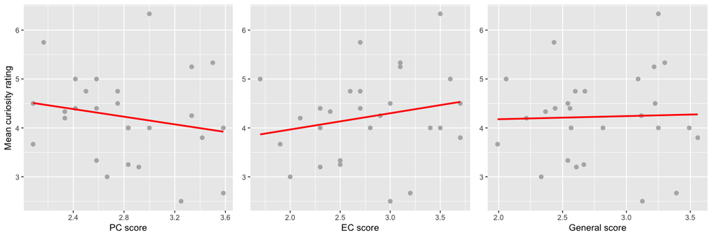

```r
cor.test(trait.ratings$meanCurRating, trait.ratings$PC, method = "pearson")
```

```
    Pearson's product-moment correlation

data:  trait.ratings$meanCurRating and trait.ratings$PC
t = -0.99893, df = 25, p-value = 0.3274
alternative hypothesis: true correlation is not equal to 0
95 percent confidence interval:
 -0.5360220  0.1989076
sample estimates:
       cor
-0.1959151
```

```r
cor.test(trait.ratings$meanCurRating, trait.ratings$EC, method = "pearson")
```

```
    Pearson's product-moment correlation

data:  trait.ratings$meanCurRating and trait.ratings$EC
t = 1.0607, df = 25, p-value = 0.2989
alternative hypothesis: true correlation is not equal to 0
95 percent confidence interval:
 -0.1872506  0.5445955
sample estimates:
      cor
0.2075308
```

```r
cor.test(trait.ratings$meanCurRating, trait.ratings$GN, method = "pearson")
```

```
    Pearson's product-moment correlation

data:  trait.ratings$meanCurRating and trait.ratings$GN
t = 0.15776, df = 25, p-value = 0.8759
alternative hypothesis: true correlation is not equal to 0
95 percent confidence interval:
 -0.3527037  0.4066774
sample estimates:
       cor
0.03153727
```

## 2.2 Only for the *novel* rooms

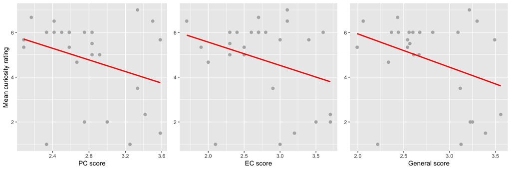

```
    Pearson's product-moment correlation

data:  trait.ratings.novel$meanCurRating and trait.ratings.novel$PC
t = -1.6295, df = 24, p-value = 0.1163
alternative hypothesis: true correlation is not equal to 0
95 percent confidence interval:
 -0.62638644  0.08173179
sample estimates:
       cor
-0.3156121


    Pearson's product-moment correlation

data:  trait.ratings.novel$meanCurRating and trait.ratings.novel$EC
t = -1.575, df = 24, p-value = 0.1283
alternative hypothesis: true correlation is not equal to 0
95 percent confidence interval:
 -0.61992279  0.09221905
sample estimates:
       cor
-0.3060659


    Pearson's product-moment correlation

data:  trait.ratings.novel$meanCurRating and trait.ratings.novel$GN
t = -1.8439, df = 24, p-value = 0.07758
alternative hypothesis: true correlation is not equal to 0
95 percent confidence interval:
 -0.65081036  0.04063588
sample estimates:
       cor
-0.3522608
```

# 3 Relationship between trait score and memory performance

Here *memory performance* refers to the average corrected hit rate for “seen” response for items and average corrected hit rate for source memory.

## 3.1 Outside

### 3.1.1 Item recollection

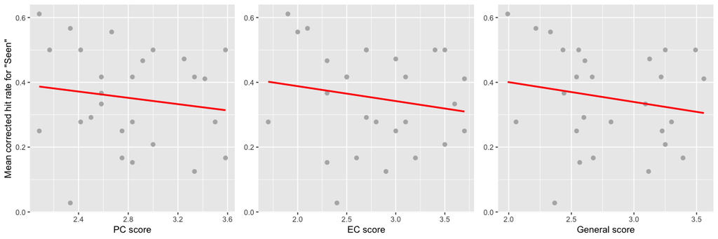

```
    Pearson's product-moment correlation

data:  outside.hit.rate.trait$meanSAcc and outside.hit.rate.trait$PC
t = -0.72697, df = 25, p-value = 0.474
alternative hypothesis: true correlation is not equal to 0
95 percent confidence interval:
 -0.4967358  0.2497899
sample estimates:
       cor
-0.1438819


    Pearson's product-moment correlation

data:  outside.hit.rate.trait$meanSAcc and outside.hit.rate.trait$EC
t = -0.85974, df = 25, p-value = 0.3981
alternative hypothesis: true correlation is not equal to 0
95 percent confidence interval:
 -0.5162309  0.2250453
sample estimates:
      cor
-0.169461


    Pearson's product-moment correlation

data:  outside.hit.rate.trait$meanSAcc and outside.hit.rate.trait$GN
t = -0.91071, df = 25, p-value = 0.3711
alternative hypothesis: true correlation is not equal to 0
95 percent confidence interval:
 -0.5235550  0.2154953
sample estimates:
      cor
-0.179193
```

### 3.1.2 Source memory

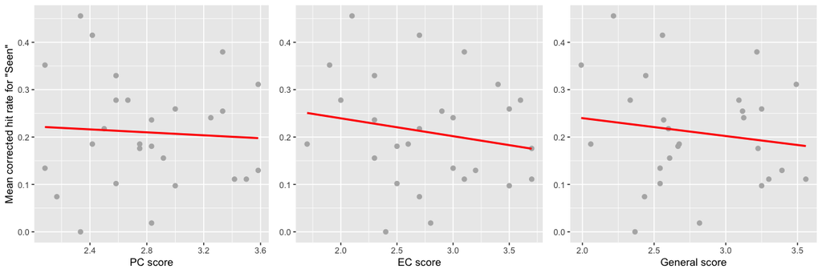

```
    Pearson's product-moment correlation

data:  outside.hit.rate.trait$meanSrcAcc and outside.hit.rate.trait$PC
t = -0.30494, df = 25, p-value = 0.7629
alternative hypothesis: true correlation is not equal to 0
95 percent confidence interval:
 -0.4309209  0.3266959
sample estimates:
        cor
-0.06087569


    Pearson's product-moment correlation

data:  outside.hit.rate.trait$meanSrcAcc and outside.hit.rate.trait$EC
t = -0.93251, df = 25, p-value = 0.36
alternative hypothesis: true correlation is not equal to 0
95 percent confidence interval:
 -0.5266615  0.2114015
sample estimates:
       cor
-0.1833412


    Pearson's product-moment correlation

data:  outside.hit.rate.trait$meanSrcAcc and outside.hit.rate.trait$GN
t = -0.73792, df = 25, p-value = 0.4674
alternative hypothesis: true correlation is not equal to 0
95 percent confidence interval:
 -0.4983661  0.2477573
sample estimates:
      cor
-0.146003
```

## 3.2 Inside

### 3.2.1 Item recollection

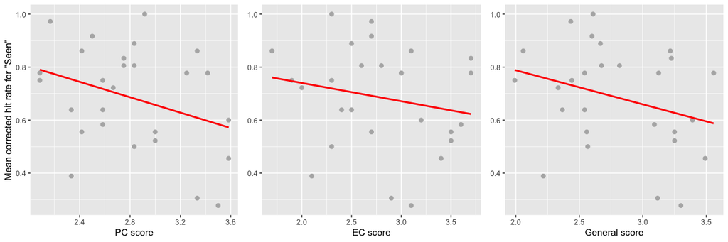

```
    Pearson's product-moment correlation

data:  inside.hit.rate.trait$meanSAcc and inside.hit.rate.trait$PC
t = -1.797, df = 25, p-value = 0.08442
alternative hypothesis: true correlation is not equal to 0
95 percent confidence interval:
 -0.63643884  0.04795005
sample estimates:
      cor
-0.338227


    Pearson's product-moment correlation

data:  inside.hit.rate.trait$meanSAcc and inside.hit.rate.trait$EC
t = -1.0196, df = 25, p-value = 0.3177
alternative hypothesis: true correlation is not equal to 0
95 percent confidence interval:
 -0.5389063  0.1950091
sample estimates:
       cor
-0.1998122


    Pearson's product-moment correlation

data:  inside.hit.rate.trait$meanSAcc and inside.hit.rate.trait$GN
t = -1.5518, df = 25, p-value = 0.1333
alternative hypothesis: true correlation is not equal to 0
95 percent confidence interval:
 -0.60794762  0.09421249
sample estimates:
       cor
-0.2964137
```

### 3.2.2 Source memory

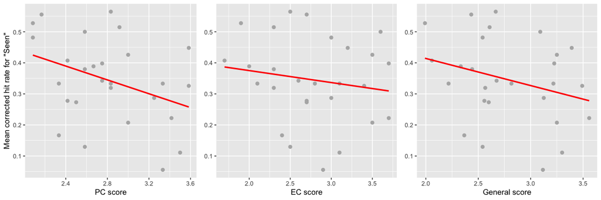

```
    Pearson's product-moment correlation

data:  inside.hit.rate.trait$meanSrcAcc and inside.hit.rate.trait$PC
t = -1.9843, df = 25, p-value = 0.05831
alternative hypothesis: true correlation is not equal to 0
95 percent confidence interval:
 -0.65681227  0.01296467
sample estimates:
       cor
-0.3688666


    Pearson's product-moment correlation

data:  inside.hit.rate.trait$meanSrcAcc and inside.hit.rate.trait$EC
t = -0.80644, df = 25, p-value = 0.4276
alternative hypothesis: true correlation is not equal to 0
95 percent confidence interval:
 -0.5084768  0.2350032
sample estimates:
       cor
-0.1592308


    Pearson's product-moment correlation

data:  inside.hit.rate.trait$meanSrcAcc and inside.hit.rate.trait$GN
t = -1.4945, df = 25, p-value = 0.1476
alternative hypothesis: true correlation is not equal to 0
95 percent confidence interval:
 -0.6009847  0.1050755
sample estimates:
       cor
-0.2863734
```

# 4 Relationship between trait score and memory performance within *Novel* rooms

Here *memory performance* refers to the average corrected hit rate for “seen” response for items and average corrected hit rate for source memory.

## 4.1 Outside

### 4.1.1 Item recollection

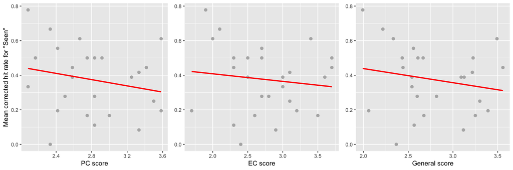

```
    Pearson's product-moment correlation

data:  outside.hit.rate.trait.novel$meanSAcc and outside.hit.rate.trait.novel$PC
t = -1.0727, df = 24, p-value = 0.2941
alternative hypothesis: true correlation is not equal to 0
95 percent confidence interval:
 -0.5552474  0.1891212
sample estimates:
       cor
-0.2139003


    Pearson's product-moment correlation

data:  outside.hit.rate.trait.novel$meanSAcc and outside.hit.rate.trait.novel$EC
t = -0.62239, df = 24, p-value = 0.5396
alternative hypothesis: true correlation is not equal to 0
95 percent confidence interval:
 -0.4894881  0.2747316
sample estimates:
       cor
-0.1260325


    Pearson's product-moment correlation

data:  outside.hit.rate.trait.novel$meanSAcc and outside.hit.rate.trait.novel$GN
t = -0.93863, df = 24, p-value = 0.3573
alternative hypothesis: true correlation is not equal to 0
95 percent confidence interval:
 -0.5364260  0.2148375
sample estimates:
       cor
-0.1881738
```

### 4.1.2 Source memory

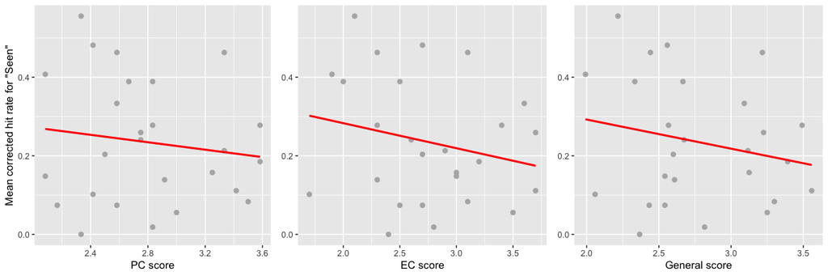

```
    Pearson's product-moment correlation

data:  outside.hit.rate.trait.novel$meanSrcAcc and outside.hit.rate.trait.novel$PC
t = -0.68173, df = 24, p-value = 0.5019
alternative hypothesis: true correlation is not equal to 0
95 percent confidence interval:
 -0.4985632  0.2635962
sample estimates:
       cor
-0.1378287


    Pearson's product-moment correlation

data:  outside.hit.rate.trait.novel$meanSrcAcc and outside.hit.rate.trait.novel$EC
t = -1.1302, df = 24, p-value = 0.2696
alternative hypothesis: true correlation is not equal to 0
95 percent confidence interval:
 -0.5631164  0.1780581
sample estimates:
       cor
-0.2247985


    Pearson's product-moment correlation

data:  outside.hit.rate.trait.novel$meanSrcAcc and outside.hit.rate.trait.novel$GN
t = -1.0546, df = 24, p-value = 0.3021
alternative hypothesis: true correlation is not equal to 0
95 percent confidence interval:
 -0.5527422  0.1926041
sample estimates:
       cor
-0.2104485
```

## 4.2 Inside

### 4.2.1 Item recollection

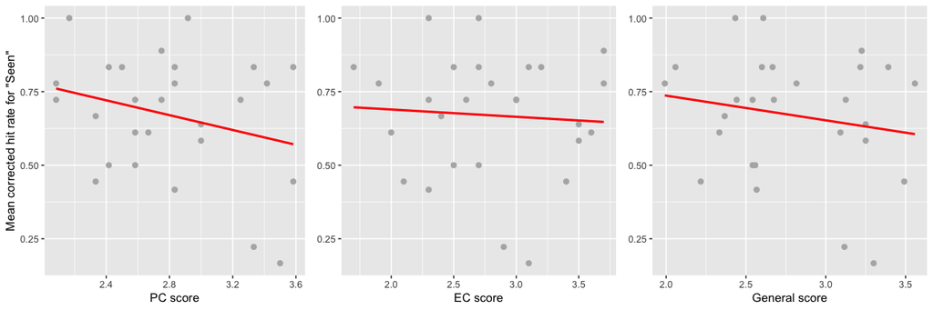

```
    Pearson's product-moment correlation

data:  inside.hit.rate.trait.novel$meanSAcc and inside.hit.rate.trait.novel$PC
t = -1.4251, df = 25, p-value = 0.1665
alternative hypothesis: true correlation is not equal to 0
95 percent confidence interval:
 -0.5924047  0.1182334
sample estimates:
       cor
-0.2740958


    Pearson's product-moment correlation

data:  inside.hit.rate.trait.novel$meanSAcc and inside.hit.rate.trait.novel$EC
t = -0.33702, df = 25, p-value = 0.7389
alternative hypothesis: true correlation is not equal to 0
95 percent confidence interval:
 -0.4361201  0.3209649
sample estimates:
        cor
-0.06725188


    Pearson's product-moment correlation

data:  inside.hit.rate.trait.novel$meanSAcc and inside.hit.rate.trait.novel$GN
t = -0.91858, df = 25, p-value = 0.3671
alternative hypothesis: true correlation is not equal to 0
95 percent confidence interval:
 -0.5246782  0.2140181
sample estimates:
       cor
-0.1806914
```

### 4.2.2 Source memory

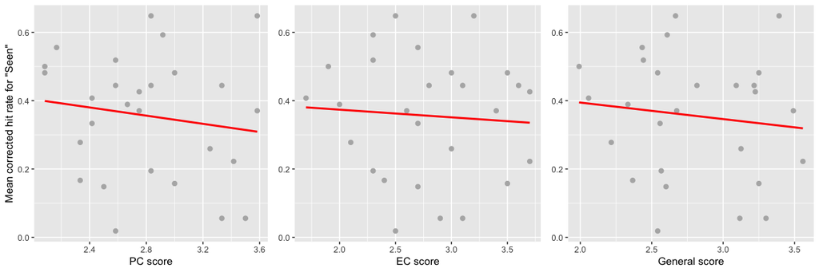

```
    Pearson's product-moment correlation

data:  inside.hit.rate.trait.novel$meanSrcAcc and inside.hit.rate.trait.novel$PC
t = -0.76198, df = 25, p-value = 0.4532
alternative hypothesis: true correlation is not equal to 0
95 percent confidence interval:
 -0.5019346  0.2432852
sample estimates:
       cor
-0.1506573


    Pearson's product-moment correlation

data:  inside.hit.rate.trait.novel$meanSrcAcc and inside.hit.rate.trait.novel$EC
t = -0.35251, df = 25, p-value = 0.7274
alternative hypothesis: true correlation is not equal to 0
95 percent confidence interval:
 -0.4386198  0.3181896
sample estimates:
        cor
-0.07032824


    Pearson's product-moment correlation

data:  inside.hit.rate.trait.novel$meanSrcAcc and inside.hit.rate.trait.novel$GN
t = -0.60586, df = 25, p-value = 0.5501
alternative hypothesis: true correlation is not equal to 0
95 percent confidence interval:
 -0.4784354  0.2721632
sample estimates:
      cor
-0.120292
```

# 5 Relationship between trait score and curiosity ratings between *Familiar* and *Novel* rooms

Here *performance difference* refers to difference in item recollection and source memory between the *novel* and *familiar* rooms (*novel* - *familiar*).

## 5.1 See whether the curiosity ratings are significantly different between *novel* and *familiar* rooms

The average curiosity rating for the *novel* rooms is 4.78 (SD = $\pm$ 1.9).

The average curiosity rating for the *familiar* rooms is 3.08 (SD = $\pm$ 1.71).

```
    One Sample t-test

data:  outside.hit.rate.trait.diff$diffRating
t = 2.4352, df = 26, p-value = 0.02205
alternative hypothesis: true mean is not equal to 0
95 percent confidence interval:
 0.2367577 2.8002794
sample estimates:
mean of x
 1.518519
```

## 5.2 See whether the difference in curiosity ratings are significantly correlated with trait scores

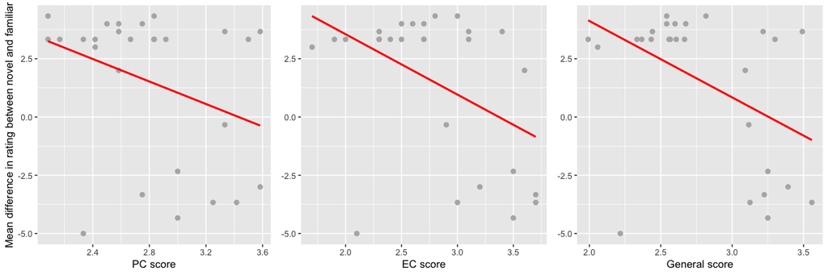

```
    Pearson's product-moment correlation

data:  outside.hit.rate.trait.diff$diffRating and outside.hit.rate.trait.diff$PC
t = -1.8012, df = 25, p-value = 0.08374
alternative hypothesis: true correlation is not equal to 0
95 percent confidence interval:
 -0.63690750  0.04716371
sample estimates:
       cor
-0.3389248


    Pearson's product-moment correlation

data:  outside.hit.rate.trait.diff$diffRating and outside.hit.rate.trait.diff$EC
t = -2.5386, df = 25, p-value = 0.01773
alternative hypothesis: true correlation is not equal to 0
95 percent confidence interval:
 -0.71049613 -0.08780639
sample estimates:
       cor
-0.4527143


    Pearson's product-moment correlation

data:  outside.hit.rate.trait.diff$diffRating and outside.hit.rate.trait.diff$GN
t = -2.5602, df = 25, p-value = 0.01689
alternative hypothesis: true correlation is not equal to 0
95 percent confidence interval:
 -0.71239100 -0.09161246
sample estimates:
       cor
-0.4557596
```

### 5.2.1 Looking at the trait-rating correlation separately for the *novel* and *familiar* rooms

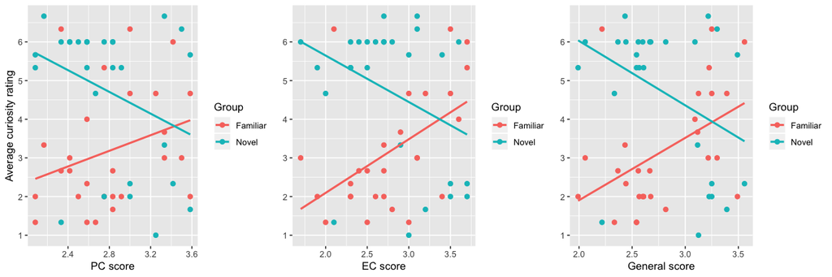

# 6 Relationship between trait score and performance differences between *Familiar* and *Novel* rooms

Here *performance difference* refers to difference in item recollection and source memory between the *novel* and *familiar* rooms (*novel* - *familiar*).

## 6.1 Outside

### 6.1.1 Item recollection

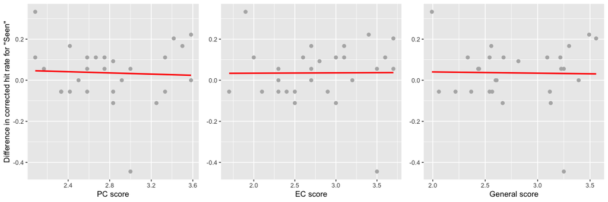

### 6.1.2 Source memory

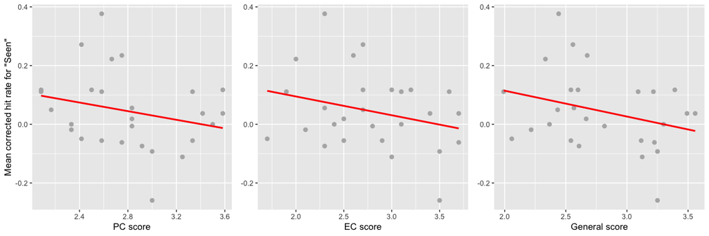

```
    Pearson's product-moment correlation

data:  outside.hit.rate.trait.diff$diffSrcAcc and outside.hit.rate.trait.diff$PC
t = -1.2977, df = 25, p-value = 0.2062
alternative hypothesis: true correlation is not equal to 0
95 percent confidence interval:
 -0.5762261  0.1423836
sample estimates:
       cor
-0.2512235


    Pearson's product-moment correlation

data:  outside.hit.rate.trait.diff$diffSrcAcc and outside.hit.rate.trait.diff$EC
t = -1.4145, df = 25, p-value = 0.1695
alternative hypothesis: true correlation is not equal to 0
95 percent confidence interval:
 -0.5910859  0.1202341
sample estimates:
       cor
-0.2722177


    Pearson's product-moment correlation

data:  outside.hit.rate.trait.diff$diffSrcAcc and outside.hit.rate.trait.diff$GN
t = -1.5609, df = 25, p-value = 0.1311
alternative hypothesis: true correlation is not equal to 0
95 percent confidence interval:
 -0.60904242  0.09248914
sample estimates:
       cor
-0.2979986
```

## 6.2 Inside

### 6.2.1 Item recollection

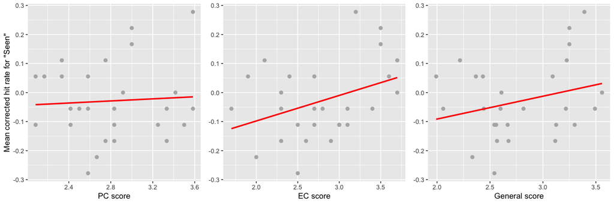

```
    Pearson's product-moment correlation

data:  inside.hit.rate.trait.diff$diffSAcc and inside.hit.rate.trait.diff$PC
t = 0.30725, df = 25, p-value = 0.7612
alternative hypothesis: true correlation is not equal to 0
95 percent confidence interval:
 -0.3262846  0.4312957
sample estimates:
       cor
0.06133438


    Pearson's product-moment correlation

data:  inside.hit.rate.trait.diff$diffSAcc and inside.hit.rate.trait.diff$EC
t = 2.0207, df = 25, p-value = 0.05414
alternative hypothesis: true correlation is not equal to 0
95 percent confidence interval:
 -0.006193439  0.660645635
sample estimates:
      cor
0.3747024


    Pearson's product-moment correlation

data:  inside.hit.rate.trait.diff$diffSAcc and inside.hit.rate.trait.diff$GN
t = 1.3827, df = 25, p-value = 0.179
alternative hypothesis: true correlation is not equal to 0
95 percent confidence interval:
 -0.1262642  0.5870876
sample estimates:
      cor
0.2665389
```

### 6.2.2 Source memory

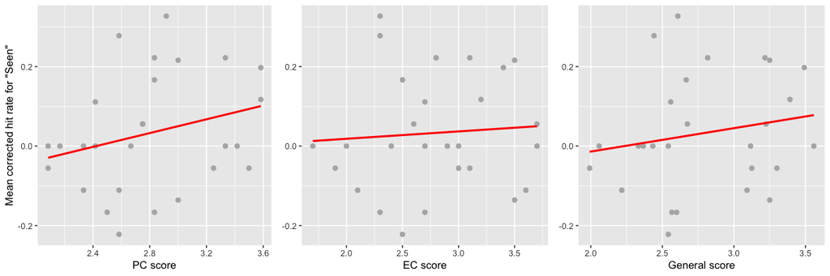

```
    Pearson's product-moment correlation

data:  inside.hit.rate.trait.diff$diffSrcAcc and inside.hit.rate.trait.diff$PC
t = 1.399, df = 25, p-value = 0.1741
alternative hypothesis: true correlation is not equal to 0
95 percent confidence interval:
 -0.1231757  0.5891398
sample estimates:
      cor
0.2694508


    Pearson's product-moment correlation

data:  inside.hit.rate.trait.diff$diffSrcAcc and inside.hit.rate.trait.diff$EC
t = 0.3596, df = 25, p-value = 0.7222
alternative hypothesis: true correlation is not equal to 0
95 percent confidence interval:
 -0.3169176  0.4397615
sample estimates:
       cor
0.07173567


    Pearson's product-moment correlation

data:  inside.hit.rate.trait.diff$diffSrcAcc and inside.hit.rate.trait.diff$GN
t = 0.92106, df = 25, p-value = 0.3658
alternative hypothesis: true correlation is not equal to 0
95 percent confidence interval:
 -0.2135512  0.5250327
sample estimates:
      cor
0.1811647
```